# ¿Cómo hacer derivadas en R Studio?

Angulo Behumea Alan Saúl, Guyot Enzo Thomas y Santiago Segura Sarahí

10/1/2021

## En este trabajo vas a aprender a realizar derivadas en R Studio (que también sirve para realizar operaciones matemáticas de manera muy sencilla) con dos métodos muy fáciles y despúes procederemos a graficarlas, para ello utilizaremos códigos de programación básicos y sencillos de utilizar.

# 1.- Lo primero que tenemos que hacer es activar las librerías que utilizaremos en uno de los métodos.

```r
library(Deriv)
```

# 2.- Para el primer método lo haremos utilizando la librería que acabamos de activar.

Primero tenemos que crear nuestra función para lo que utilizaremos function para crear nuestra función:

```r
f<-function(x) 2*x^2+2
f
```

```
## function(x) 2*x^2+2
```

Después utilizaremos el código Deriv para calcular la derivada de la siguiente manera:

```r
fprima<-Deriv(f, "x")
fprima
```

```
## function (x)
## 4 * x
```

Y así obtemos la derivada de nuestra función.

# 3.- Para el segundo método lo haremos aún más fácil sin la necesidad de usar ninguna librería.

De igual manera tenemos que crear nuestra función pero esta vez usaremos el código expression ya que con ese código es con el que R puede hacer derivadas sin la librería:

```r
g<-expression(y^3+3*y^2)
g
```

```
## expression(y^3 + 3 * y^2)
```

Posteriormente usamos el código D para obtener la derivada de nuestra función:

```r
gprima<-D(g,"y")
gprima
```

```
## 3 * y^2 + 3 * (2 * y)
```

# 4.- Posteriormente crearemos un dominio a nuestra primera función para graficarla despúes.

Para crear nuestro dominio usaremos el código seq:

```r
x<-seq(-3,3,0.1)
x
```

```
##  [1] -3.0 -2.9 -2.8 -2.7 -2.6 -2.5 -2.4 -2.3 -2.2 -2.1 -2.0 -1.9 -1.8 -1.7 -1.6
## [16] -1.5 -1.4 -1.3 -1.2 -1.1 -1.0 -0.9 -0.8 -0.7 -0.6 -0.5 -0.4 -0.3 -0.2 -0.1
## [31]  0.0  0.1  0.2  0.3  0.4  0.5  0.6  0.7  0.8  0.9  1.0  1.1  1.2  1.3  1.4
## [46]  1.5  1.6  1.7  1.8  1.9  2.0  2.1  2.2  2.3  2.4  2.5  2.6  2.7  2.8  2.9
## [61]  3.0
```

# 5.- Graficar nuestra función.

Para hacer una gráfica de nuestra función y de su derivada tendremos que utilizar necesariamente nuestro primer método y el código plot:

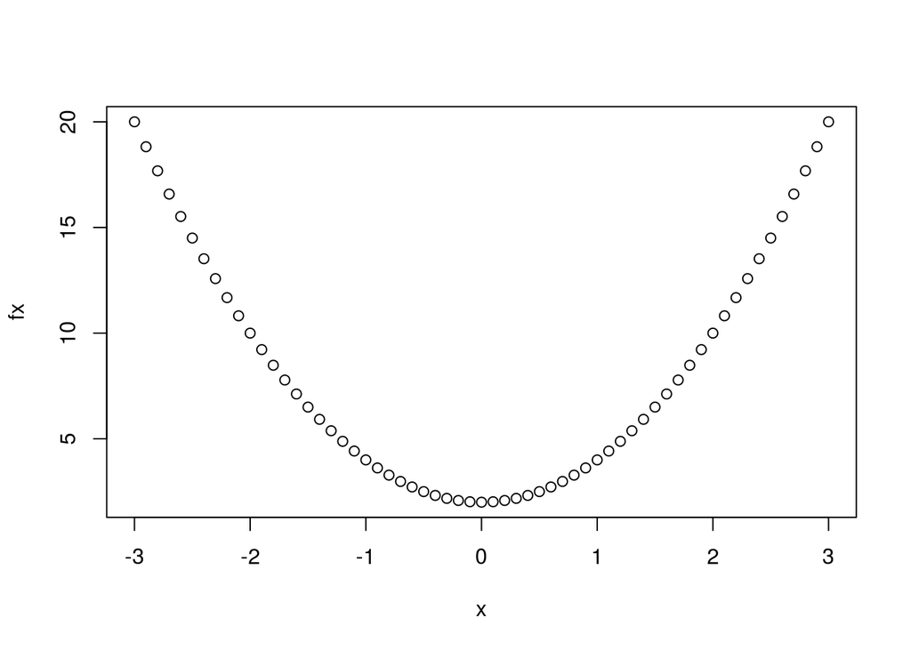

```r
fx<-f(x)
plot(x,fx)
```

Ahora graficaremos la derivada de nuestra funcion de la siguiente manera:

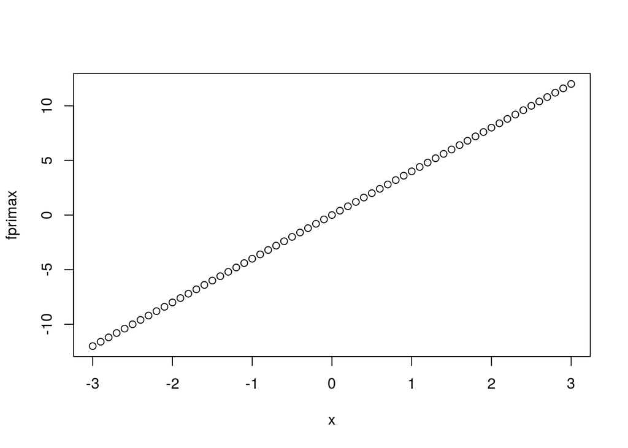

```r
fprimax<-fprima(x)
plot(x,fprimax)
```

# 6.- Video.

Por último insertamos un video en donde explicamos paso a paso como hacer derivadas sin ningun programa para que aprendas a hacerlo manuelmente y no llegues a depender necesariamente de este tipo de programas. Esperamos que te haya servido nuestro tutorial de como hacer derivadas en R Studio. El link del video es: https://youtu.be/CBIR-94CKvE